# 10 Raster : Corse

Author

Dr. Elisabetta Pietrostefani

Published

March 21, 2026

**Corrigé — à consulter après avoir essayé par vous-mêmes**

Ce document contient les réponses complètes à l’exercice Corse posé à la fin de Raster : Indices Topographiques. Essayez d’abord par vous-mêmes avant de consulter ce corrigé.

```r
library(terra)
library(tidyterra)
library(sf)
library(ggplot2)
library(dplyr)
library(scales)
```

## 10.1 Exercice 1 — Charger le MNT

Deux options sont disponibles selon les fichiers à disposition.

**Option A — MNT complet déjà assemblé (plus simple)**

```r
dem_corse <- rast("data/France/Corse/Corse_tout_lambert.tif")

cat("SCR        :", crs(dem_corse, describe = TRUE)$name, "\n")
```

```
SCR        : RGF93 v1 / Lambert-93
```

```r
cat("Résolution :", res(dem_corse), "\n")
```

```
Résolution : 27.27336 27.27336
```

```r
cat("Min / Max  :", global(dem_corse, "min", na.rm = TRUE)[[1]], "/",
                    global(dem_corse, "max", na.rm = TRUE)[[1]], "m\n")
```

```
Min / Max  : -12 / 2664 m
```

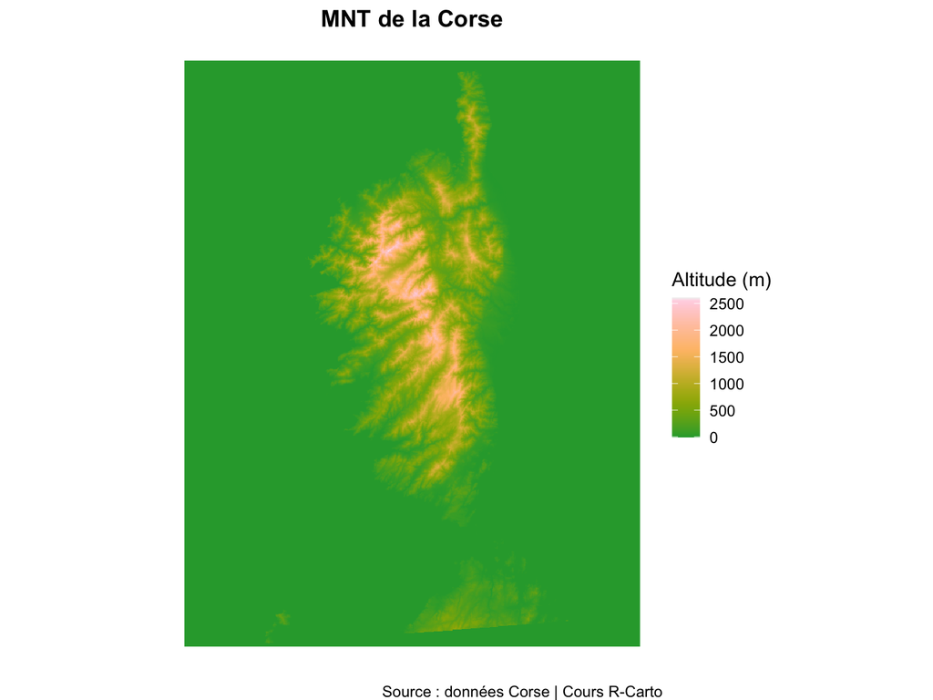

MNT de la Corse — Lambert-93

```r
ggplot() +
  geom_spatraster(data = dem_corse) +
  scale_fill_gradientn(
    colors   = hcl.colors(50, "Terrain"),
    name     = "Altitude (m)",
    na.value = "transparent"
  ) +
  labs(title   = "MNT de la Corse",
       caption = "Source : données Corse | Cours R-Carto") +
  theme_void(base_size = 12) +
  theme(plot.title = element_text(face = "bold", hjust = 0.5))
```

**Option B — Assembler les 4 tuiles avec `mosaic()`**

```r
t1 <- rast("data/France/Corse/DEM_corse_1.tif")
t2 <- rast("data/France/Corse/DEM_corse_2.tif")
t3 <- rast("data/France/Corse/DEM_corse_3.tif")
t4 <- rast("data/France/Corse/DEM_corse_4.tif")

dem_corse <- mosaic(t1, t2, t3, t4, fun = "mean")
```

**Quand utiliser `mosaic()` ?**

Les MNT à haute résolution couvrant un territoire étendu sont souvent distribués en **tuiles** pour des raisons de taille de fichier. `mosaic()` les assemble en un seul raster en appliquant une fonction (ici `"mean"`) aux cellules qui se chevauchent sur les bords.

## 10.2 Exercice 2 — Calculer la pente

On utilise `DEM_corse_1_Lambert93.tif` — déjà projeté en mètres. Le SCR en mètres est **indispensable** : avec des coordonnées en degrés, les valeurs de pente seraient fausses car les unités horizontales et verticales seraient incompatibles.

```r
dem_corse_m <- rast("data/France/Corse/DEM_corse_1_Lambert93.tif")

slope_corse <- terrain(dem_corse_m, v = "slope", unit = "degrees")

cat("Pente moyenne :", round(global(slope_corse, "mean", na.rm = TRUE)[[1]], 1), "°\n")
```

```
Pente moyenne : 7.5 °
```

```r
cat("Pente max     :", round(global(slope_corse, "max",  na.rm = TRUE)[[1]], 1), "°\n")
```

```
Pente max     : 76.7 °
```

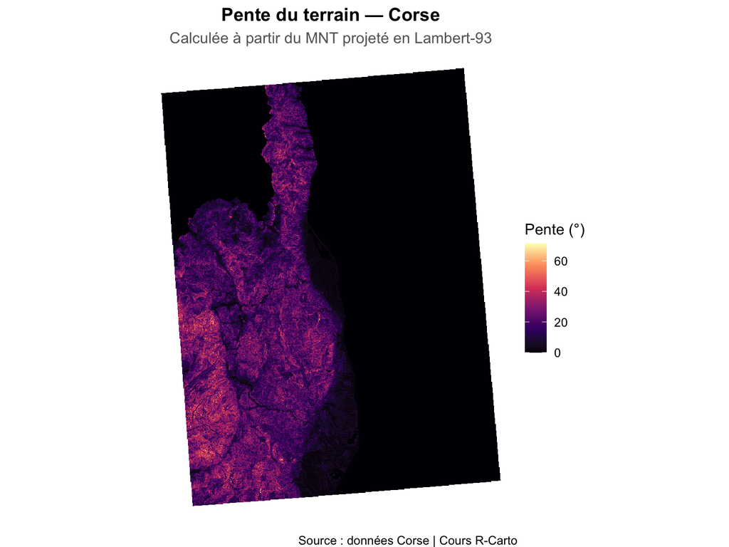

Figure 10.1: Pente du terrain — Corse (degrés)

```r
ggplot() +
  geom_spatraster(data = slope_corse) +
  scale_fill_viridis_c(
    option   = "magma",
    name     = "Pente (°)",
    na.value = "transparent"
  ) +
  labs(title    = "Pente du terrain — Corse",
       subtitle = "Calculée à partir du MNT projeté en Lambert-93",
       caption  = "Source : données Corse | Cours R-Carto") +
  theme_void(base_size = 12) +
  theme(plot.title    = element_text(face = "bold", hjust = 0.5),
        plot.subtitle = element_text(color = "grey40", hjust = 0.5))
```

## 10.3 Exercice 3 — Reclassifier en zones altitudinales

```r
rcl_corse <- matrix(c(
     0,  200, 1,   # Littoral
   200,  800, 2,   # Basse montagne
   800, 1500, 3,   # Montagne
  1500,  Inf, 4    # Haute montagne
), ncol = 3, byrow = TRUE)

corse_zones <- classify(dem_corse, rcl_corse)

# Résumé par zone — group and sum to handle any floating point values
freq_zones <- freq(corse_zones) |>
  filter(value %in% 1:4) |>
  group_by(value) |>
  summarise(count = sum(count), .groups = "drop") |>
  mutate(
    pct  = round(count / sum(count) * 100, 1),
    zone = case_when(
      value == 1 ~ "Littoral (0–200 m)",
      value == 2 ~ "Basse montagne (200–800 m)",
      value == 3 ~ "Montagne (800–1500 m)",
      value == 4 ~ "Haute montagne (> 1500 m)"
    )
  )

knitr::kable(freq_zones[, c("zone", "count", "pct")],
             col.names = c("Zone", "Cellules", "Part (%)"),
             caption   = "Répartition des cellules par zone altitudinale")
```

Répartition des cellules par zone altitudinale

| Zone | Cellules | Part (%) |
| --- | --- | --- |
| Littoral (0–200 m) | 4417445 | 33.7 |
| Basse montagne (200–800 m) | 5427988 | 41.5 |
| Montagne (800–1500 m) | 2542799 | 19.4 |
| Haute montagne (> 1500 m) | 704019 | 5.4 |

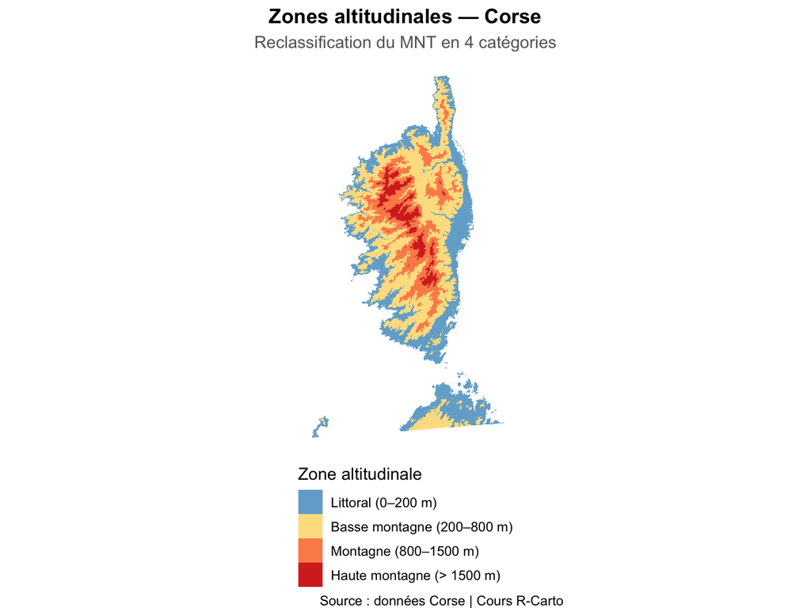

Figure 10.2: Zones altitudinales de la Corse — reclassification en 4 catégories

```r
ggplot() +
  geom_spatraster(data = as.factor(corse_zones)) +
  scale_fill_manual(
    values   = c("1" = "#74add1", "2" = "#fee090",
                 "3" = "#fc8d59", "4" = "#d73027"),
    labels   = c("1" = "Littoral (0–200 m)",
                 "2" = "Basse montagne (200–800 m)",
                 "3" = "Montagne (800–1500 m)",
                 "4" = "Haute montagne (> 1500 m)"),
    name     = "Zone altitudinale",
    na.value = "transparent"
  ) +
  labs(title    = "Zones altitudinales — Corse",
       subtitle = "Reclassification du MNT en 4 catégories",
       caption  = "Source : données Corse | Cours R-Carto") +
  theme_void(base_size = 12) +
  theme(plot.title       = element_text(face = "bold", hjust = 0.5),
        plot.subtitle    = element_text(color = "grey40", hjust = 0.5),
        legend.position  = "bottom",
        legend.direction = "vertical")
```

## 10.4 Exercice Bonus — Comparer Liban et Corse

```r
stats <- data.frame(
  territoire = c("Liban", "Corse"),
  alt_moy    = c(
    global(rast("data/Liban/LBN_elevation_w_bathymetry.tif"), "mean", na.rm = TRUE)[[1]],
    global(dem_corse, "mean", na.rm = TRUE)[[1]]
  ),
  alt_max    = c(
    global(rast("data/Liban/LBN_elevation_w_bathymetry.tif"), "max",  na.rm = TRUE)[[1]],
    global(dem_corse, "max",  na.rm = TRUE)[[1]]
  ),
  superficie_km2 = c(10452, 8680)
)

knitr::kable(stats, digits = 0,
             col.names = c("Territoire", "Altitude moy. (m)",
                           "Altitude max. (m)", "Superficie (km²)"),
             caption = "Comparaison topographique Liban / Corse")
```

Comparaison topographique Liban / Corse

| Territoire | Altitude moy. (m) | Altitude max. (m) | Superficie (km²) |
| --- | --- | --- | --- |
| Liban | -680 | 3065 | 10452 |
| Corse | 119 | 2664 | 8680 |

> **← Retour au cours : Raster : Indices Topographiques** **→ Suivant : Analyse Avancée**

*Dr. Elisabetta Pietrostefani — Directrice Adjointe, Geographic Data Science Lab — Université de Liverpool | Co-Directrice, [Imago : Data Service for Imagery](https://imago.ac.uk/) | Chercheuse Associée, London School of Economics*